# M=1, R=.7 [Adjusted analyses]

Compensatory Plasticity in glioma patients (sample entropy, rs-fMRI)

Author

Jonas Festor

## Statistical Analysis for Hypothesis 1 through 3 (Version 3)

Overview of the hypothesis:  
H1: Entropy patterns of healthy controls differ from HGG / LGG patients (intratumoral tissue, peritumoral tissue, distant ipsilateral regions and contralateral hemisphere)

H2: Significant differences in entropy scores between LGG and HGG patients are observable (intratumoral tissue, peritumoral tissue, distant ipsilateral regions and contralateral hemisphere);

H3: HGG compared to LGG will show a consistent pattern of either higher or lower entropy across different regions of interest.

## Structure of this Document

This document starts off with clarifying some prerequisites of data-preparation followed by statistical analysis.

The first few R-blocks of the analysis are about evaluating hypothesis 1, followed by the analysis of hypotheses 2 and 3. Post-hoc tests (e.g., dependent sample t-test) will be included, while Bonferonni correction is used when needed. Main effects are also specified.

Regarding the assumptions:  
The assumptions are checked before performing the respective tests (mainly mixed ANOVA). Arguments for/against the robustness will be appended. One of the most relevant assumptions is the sphericity assumption, which is not explicitly performed within the code but adjustments take place by executing the mixed ANOVA.  
See excerpt: “*The assumption of sphericity will be automatically checked during the computation of the ANOVA test using the R function ’anova_test() [rstatix package]. The Mauchly’s test is internally used to assess the sphericity assumption. By using the function get_anova_table() [rstatix] to extract the ANOVA table, the Greenhouse-Geisser sphericity correction is automatically applied*” (https://www.datanovia.com/en/lessons/mixed-anova-in-r/#assumptions).  
In this case, the correction is applied to every factor irrespective of the result of the GG test.

In greater detail, the analyses follow this structure  
1. Hypothesis 1: Assumptions (& outlier correction)  
2. Testing Hypothesis 1  
3. Visualizing Hypothesis 1  
4. Hypothesis 2-3: Assumptions  
5. Testing Hypothesis 2-3  
6. Visualize Hypothesis 2-3  
7. Visualizations across Hypotheses

PLEASE NOTE: This analyses are the latest ones including regressing out regional ROIs volume and base-line adjustments. These leads to limitations in the interpretability by some visualizations. Therefore, due to few difference with the adjustment visualizations should rather be performed without subsequent adjustment (e.g., residual plots stay interpretable)

## Prerequisites for the Analysis

Set the working directory, install and/or load necessary packages, and prepare and read the data-files.  
In greater detail, if you haven’t already installed the packages you have to use the command *install.packages(“name”)* at the very beginning (for each of them separately). Please edit the setwd path to fit your working directory.

To execute different analyses with different parameters you will need to  
1. Press “CTR+F”  
2. Type in **Find** “1_7”  
3. Type in **Replace** the suited parameters like “m_r” (e.g., 1_35 without any dot before r parameter)  
4. Click on **All** to replace all  
5. The question marks (search m=1, r=.7) should also be filled in separately so that the visualizations state which analysis was conducted.

```r
setwd("./")

# Please note:
# Parameters used are mentioned in the title of the file and variables
# For each parameter I decided to create two files for convenience in the analysis # "All" includes HC and Glioma data (important for H1), while "glioma" includes HGG and LGG only (relevant for H2,H3)


# I. Open Data
library(openxlsx)

data_all_1_7 = read.xlsx("1_7_Jonas_Wouter_version_final - across participants.xlsx")
data_glioma_1_7 = read.xlsx("1_7_Jonas_Wouter_version_final - across participants - selection - H2H3.xlsx")


# II. Load necessary packages for the analysis
library(tidyverse) # Version 2.0.0
library(ggpubr)    # Version 0.6.0
library(rstatix)   # Version 0.7.2
library(ggplot2)   # Version 3.5.0
library(reshape2)  # Version 1.4.4
library(corrplot)  # Version 0.92 (just used in preliminary analysis)
library(dplyr)     # Version 1.1.4
library(broom)     # Version 1.0.5
library(ggResidpanel) # Version 0.3.0
library(asbio)     # Version 1.9.7
```

### Gather (baseline corrected) Data and Regress Out Volume

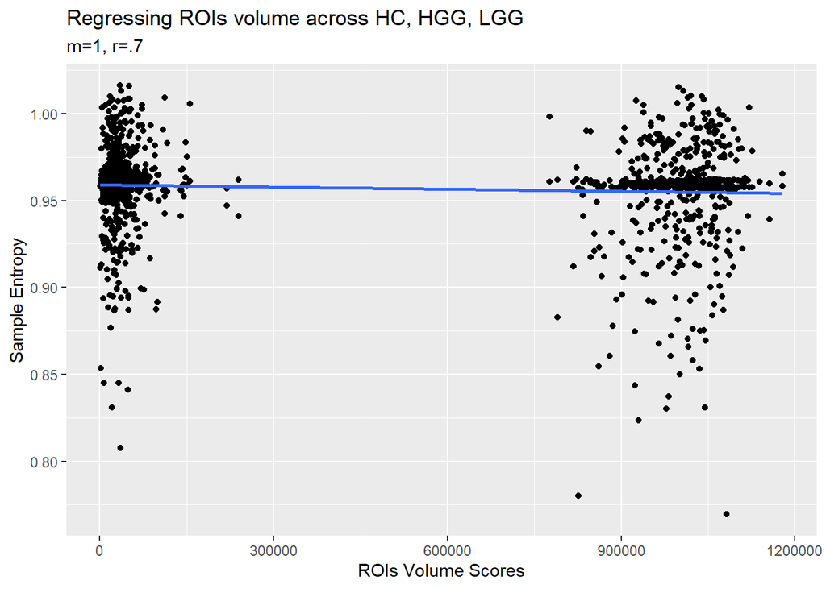

```r
# III. Gather Data
# 4 regions are in different columns, which is a problem for the analysis.
# Via long-format create one variable out of all entropy measures.
# Also the ROIs volumes need to be added to within one column.

# III.I For hypothesis 1
data_across_regions_1_7_1 = gather(data_all_1_7, key = "en_variable", value = "score", starts_with("en_tumor_1_7"), starts_with("en_peri_1_7"), starts_with("en_ipsi_1_7"), starts_with("en_contra_1_7"))

data_across_regions_1_7_2 = gather(data_all_1_7, key = "volume", value = "volume_score", starts_with("tumor_volume_mm3"), starts_with("peri_volume_mm3"), starts_with("ipsi_volume_mm3"), starts_with("contra_volume_mm3"))

data_across_regions_1_7 = cbind(data_across_regions_1_7_1, volume = data_across_regions_1_7_2$volume, volume_score= data_across_regions_1_7_2$volume_score)

# III.II For hypothesis 2-3 (here use baseline-adjusted values)
data_across_regions_H2_H3_1_7_1 = gather(data_glioma_1_7, key = "en_variable", value = "score", starts_with("baselinecorrected_tumor"), starts_with("baselinecorrected_peritumor"), starts_with("baselinecorrected_ipsilateral"), starts_with("baselinecorrected_contralateral"))

data_across_regions_H2_H3_1_7_2 = gather(data_glioma_1_7, key = "volume", value = "volume_score", starts_with("tumor_volume_mm3"), starts_with("peri_volume_mm3"), starts_with("ipsi_volume_mm3"), starts_with("contra_volume_mm3"))

data_across_regions_H2_H3_1_7 = cbind(data_across_regions_H2_H3_1_7_1, volume = data_across_regions_H2_H3_1_7_2$volume, volume_score = data_across_regions_H2_H3_1_7_2$volume_score)

# Just for comparing pre and post-correlation in next block
PreH1 = cor(data_across_regions_1_7$score, data_across_regions_1_7$volume_score)
PreH23 = cor(data_across_regions_H2_H3_1_7$score, data_across_regions_H2_H3_1_7$volume_score)



# Pre-screen relationship between ROI's volume and entropy values
# Create the scatterplot with regression lines
ggplot(data_across_regions_1_7, aes(x = volume_score, y = score)) +
  geom_point() +
  geom_smooth(method = "lm", se = FALSE) +
  ggtitle("Regressing ROIs volume across HC, HGG, LGG") +
  xlab("ROIs Volume Scores") +
  ylab("Sample Entropy") +
  labs(subtitle = "m=1, r=.7")
```

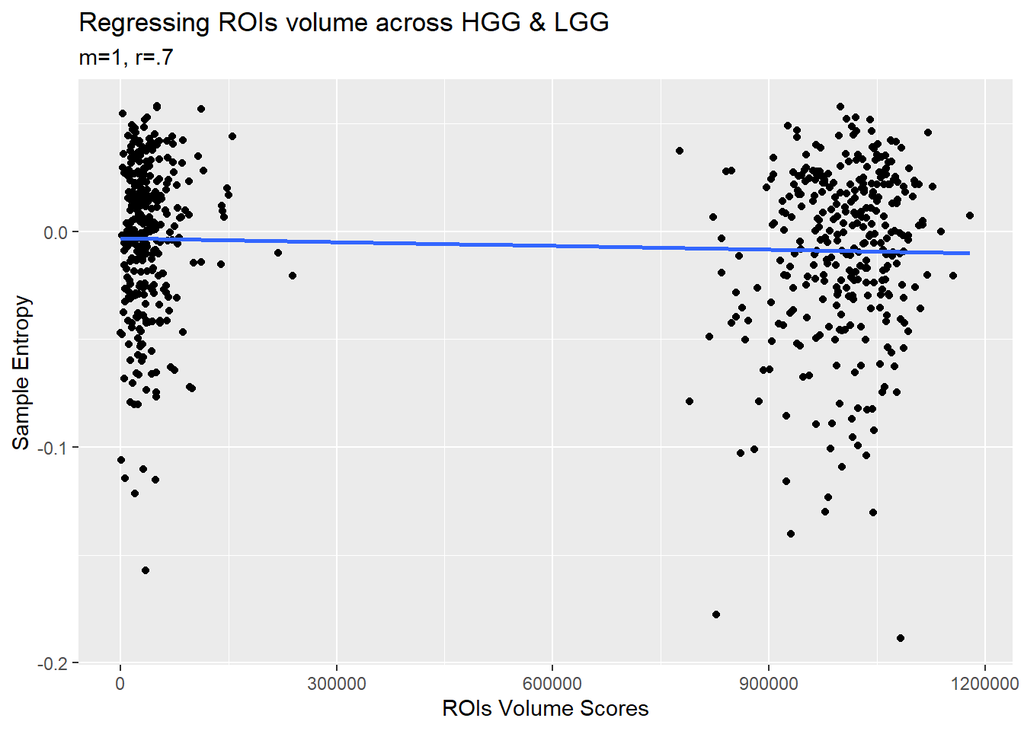

```r
ggplot(data_across_regions_H2_H3_1_7, aes(x = volume_score, y = score)) +
  geom_point() +
  geom_smooth(method = "lm", se = FALSE) +
  ggtitle("Regressing ROIs volume across HGG & LGG") +
  xlab("ROIs Volume Scores") +
  ylab("Sample Entropy") +
  labs(subtitle = "m=1, r=.7")
```

```r
# IV Regress out (r_o) ROIs volumes (across regions) for H1-H3 from entropy
# In this case unstandardized residuals once are extracted
# Keep in mind that the original variables will be overwritten

# IV.I H1 (+overall visualizations)
r_o_volumes = lm(score ~ volume_score, data = data_across_regions_1_7)
data_across_regions_1_7$score = residuals(r_o_volumes)

# IV.II H2-H3
r_o_volumes_g = lm(score ~ volume_score, data = data_across_regions_H2_H3_1_7)
data_across_regions_H2_H3_1_7$score = residuals(r_o_volumes_g)

# Just for comparing pre and post-correlation in next block
PostH1 = cor(data_across_regions_1_7$score, data_across_regions_1_7$volume_score)
PostH23 = cor(data_across_regions_H2_H3_1_7$score, data_across_regions_H2_H3_1_7$volume_score)
```

### Double Check Quality of regression

```r
# JUST FOR MORE INFORMATION ABOUT DENOISING

# If you want to gather more information of regressing out the volume:
summary(lm(score ~ volume_score, data = data_across_regions_1_7))
```

```
Call:
lm(formula = score ~ volume_score, data = data_across_regions_1_7)

Residuals:
      Min        1Q    Median        3Q       Max
-0.185275 -0.002850  0.003353  0.007844  0.060376

Coefficients:
               Estimate Std. Error t value Pr(>|t|)
(Intercept)  -7.831e-19  1.105e-03       0        1
volume_score -7.230e-25  1.553e-09       0        1

Residual standard error: 0.02701 on 1286 degrees of freedom
Multiple R-squared:  2.555e-33, Adjusted R-squared:  -0.0007776
F-statistic: 3.286e-30 on 1 and 1286 DF,  p-value: 1
```

```r
summary(lm(score ~ volume_score, data = data_across_regions_H2_H3_1_7))
```

```
Call:
lm(formula = score ~ volume_score, data = data_across_regions_H2_H3_1_7)

Residuals:
      Min        1Q    Median        3Q       Max
-0.179255 -0.020739  0.006987  0.027618  0.066634

Coefficients:
               Estimate Std. Error t value Pr(>|t|)
(Intercept)   6.929e-19  2.200e-03       0        1
volume_score -2.115e-24  3.091e-09       0        1

Residual standard error: 0.03802 on 642 degrees of freedom
Multiple R-squared:  2.469e-33, Adjusted R-squared:  -0.001558
F-statistic: 1.585e-30 on 1 and 642 DF,  p-value: 1
```

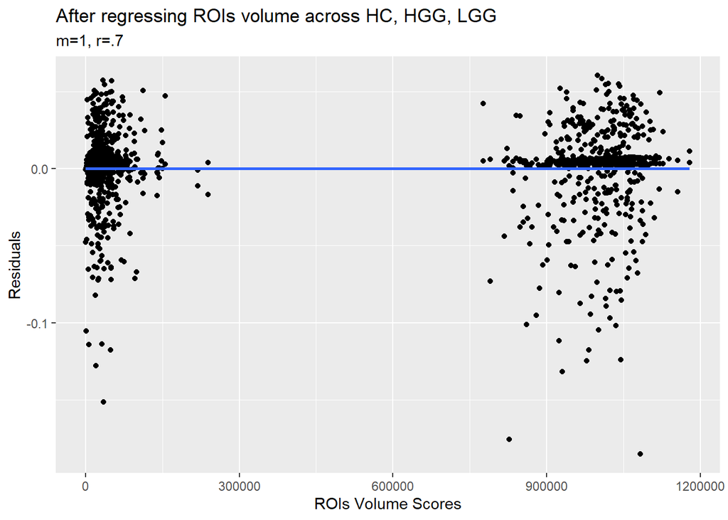

```r
#View(residuals(r_o_volumes))
#View(residuals(r_o_volumes_g))


# Relationship between ROI's volume and entropy values after correction
# Create the scatterplot with regression lines
ggplot(data_across_regions_1_7, aes(x = volume_score, y = score)) +
  geom_point() +
  geom_smooth(method = "lm", se = FALSE) +
  ggtitle("After regressing ROIs volume across HC, HGG, LGG") +
  xlab("ROIs Volume Scores") +
  ylab("Residuals") +
  labs(subtitle = "m=1, r=.7")
```

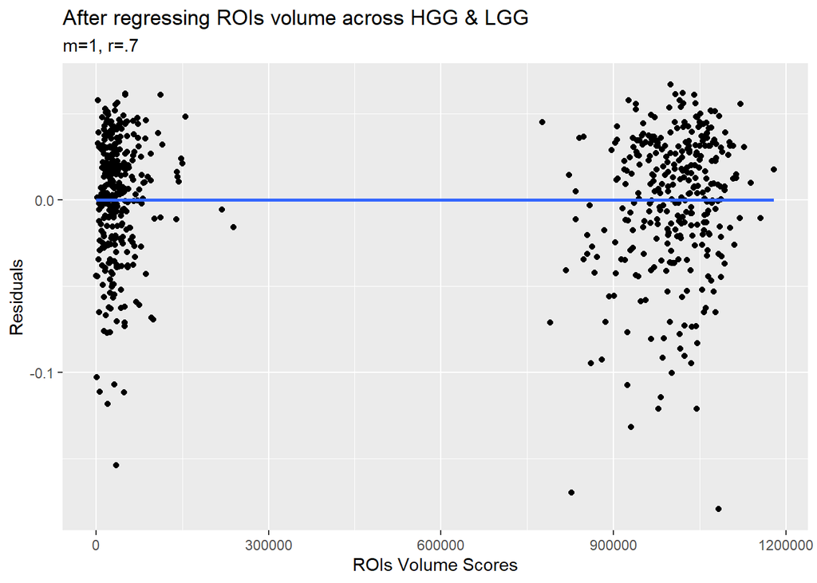

```r
ggplot(data_across_regions_H2_H3_1_7, aes(x = volume_score, y = score)) +
  geom_point() +
  geom_smooth(method = "lm", se = FALSE) +
  ggtitle("After regressing ROIs volume across HGG & LGG") +
  xlab("ROIs Volume Scores") +
  ylab("Residuals") +
  labs(subtitle = "m=1, r=.7")
```

```r
# Correlational Matrix quantifying reduction of ROIs volume influence upon entropy
correlation_data <- data.frame(
  Hypotheses = c("H1", "H2/H3"),
  Original = c(PreH1, PreH23),
  Residuals = c(PostH1, PostH23)
)

correlation_data
```

```
  Hypotheses    Original     Residuals
1         H1 -0.07320074  1.390431e-17
2      H2/H3 -0.07459736 -3.660196e-17
```

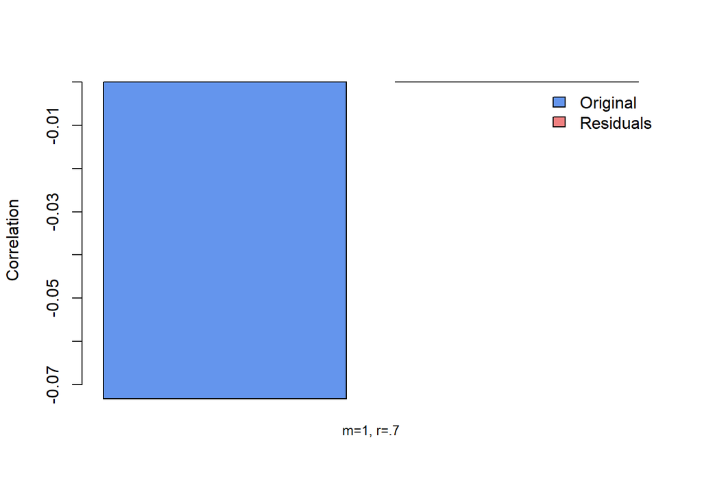

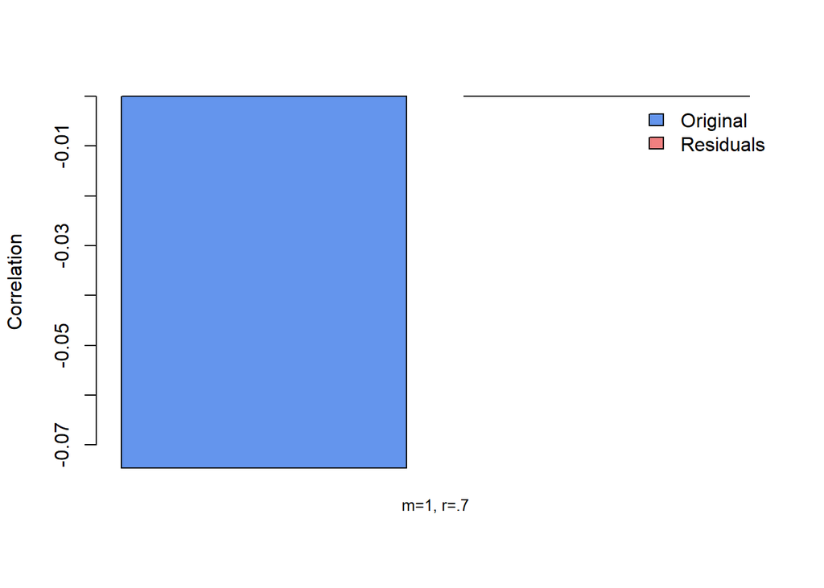

```r
# Create bar plot for each region
for (i in 1:nrow(correlation_data)) {
  bar_data <- correlation_data[i, ]
  bar_names <- bar_data$Region
  bar_values <- as.numeric(bar_data[-1])

  # Determine ylim for each plot
  ylim <- range(bar_values)

  # Create new plot for each region with specific y-axis scale
  barplot(bar_values, names.arg = bar_names, beside = TRUE, col = c("cornflowerblue", "lightcoral"),
          main = paste(bar_names), ylab = "Correlation",
          legend.text = c("Original", "Residuals"), args.legend = list(x = "topright", bty = "n"), ylim = ylim)

# Add a subtitle
mtext("m=1, r=.7", side = 1, line = 1, cex = 0.8)
}
```

## Hypothesis 1: Assumptions and Outlier correction

```r
# Identify Outliers
outliers_H1 <- data_across_regions_1_7 %>%
  group_by(en_variable, Glioma_HC) %>%
  identify_outliers(score)

outliers_H1 %>% # Report as.outlier
  select(en_variable, Glioma_HC, score) %>%
  print(n = Inf)
```

```
# A tibble: 21 × 3
   en_variable   Glioma_HC   score
   <chr>         <chr>       <dbl>
 1 en_contra_1_7 Glioma    -0.124
 2 en_contra_1_7 Glioma    -0.185
 3 en_contra_1_7 Glioma    -0.125
 4 en_contra_1_7 Glioma    -0.0969
 5 en_contra_1_7 Glioma    -0.102
 6 en_contra_1_7 Glioma    -0.0944
 7 en_contra_1_7 Glioma    -0.118
 8 en_ipsi_1_7   Glioma    -0.176
 9 en_ipsi_1_7   Glioma    -0.132
10 en_peri_1_7   Glioma    -0.0822
11 en_peri_1_7   HC        -0.0112
12 en_peri_1_7   HC        -0.0264
13 en_peri_1_7   HC        -0.0241
14 en_tumor_1_7  Glioma    -0.106
15 en_tumor_1_7  Glioma    -0.118
16 en_tumor_1_7  Glioma    -0.114
17 en_tumor_1_7  Glioma    -0.151
18 en_tumor_1_7  Glioma    -0.128
19 en_tumor_1_7  Glioma    -0.114
20 en_tumor_1_7  HC        -0.0189
21 en_tumor_1_7  HC        -0.0196
```

```r
outliers_H1_extreme = filter(outliers_H1, is.extreme == TRUE)

outliers_H1_extreme %>% # Report as.extreme_outliers
  print(n = Inf)
```

```
# A tibble: 4 × 32
  Glioma_HC en_variable   Id    Nr    PatientNr sex    education_years
  <chr>     <chr>         <chr> <chr> <chr>     <chr>            <dbl>
1 Glioma    en_contra_1_7 81    81    1184      female              13
2 HC        en_peri_1_7   212   51    <NA>      <NA>                NA
3 HC        en_peri_1_7   311   150   <NA>      <NA>                NA
4 Glioma    en_tumor_1_7  128   128   1737      male                14
# ℹ 25 more variables: education_Verhage <dbl>, education_low <chr>,
#   education_high <chr>, education_total <chr>, Bijz_PA_diagn <chr>,
#   PA_diagnose <chr>, Gedrag_tumor <chr>, Diffgrad_tumor <chr>, Grading <chr>,
#   HGG_LGG <chr>, NPS_0_NPS_afname_T0_ja_nee <chr>, age_T0 <dbl>,
#   tumor_volume_mm3 <dbl>, peri_volume_mm3 <dbl>, ipsi_volume_mm3 <dbl>,
#   contra_volume_mm3 <dbl>, baselinecorrected_tumor <dbl>,
#   baselinecorrected_peritumor <dbl>, baselinecorrected_ipsilateral <dbl>, …
```

```r
# Row counts are included to see if exclusion worked correctly
# Old row - new row = extreme_outlier*4 (whole participant excluded)
row_count <- nrow(data_across_regions_1_7)
row_count
```

```
[1] 1288
```

```r
# Pull ID numbers to exclude
# Exclusion by ID numbers to sustain paired sample t-tests later on
# In other words extreme outlier are excluded and would lead to missing data
# Missing data will unequalize the groups making paired (dependent) post hoc tests impossible
# Instead exclude participant as a whole (all 4 observations from data set)
# This is justifiable with the very small proportion of actual exclusions
data_across_regions_1_7_corrected <- data_across_regions_1_7 %>%
  anti_join(outliers_H1_extreme, by = "Id")


# you can either use the filtered (extreme) or general outlier version; in this case extreme if you want to use the code yourself

#IMPORTANT: If you want to reproduce with SPSS you need to make this part unusable by putting appropriate hashtags!
#    'data_across_regions_1_7_corrected <- data_across_regions_1_7 # %>%'
#    '#anti_join(.....)'

# 'anti_join' removes rows from the dataset that have a match in this case with Id.
# Now 'cleaned_data' = data_across_regions_1_7_corrected contains all the data except for the identified outliers subjects (across the 4 ROIs)

row_count <- nrow(data_across_regions_1_7_corrected)
row_count
```

```
[1] 1272
```

```r
# Testing Assumptions


# Normality assumptions
# Normality per condition
data_across_regions_1_7_corrected %>%
  group_by(en_variable, Glioma_HC) %>%
  shapiro_test(score)
```

```
# A tibble: 8 × 5
  Glioma_HC en_variable   variable statistic        p
  <chr>     <chr>         <chr>        <dbl>    <dbl>
1 Glioma    en_contra_1_7 score        0.927 3.08e- 7
2 HC        en_contra_1_7 score        0.850 1.93e-11
3 Glioma    en_ipsi_1_7   score        0.939 2.60e- 6
4 HC        en_ipsi_1_7   score        0.976 6.43e- 3
5 Glioma    en_peri_1_7   score        0.961 2.02e- 4
6 HC        en_peri_1_7   score        0.987 1.29e- 1
7 Glioma    en_tumor_1_7  score        0.935 1.18e- 6
8 HC        en_tumor_1_7  score        0.971 2.01e- 3
```

```r
# Normality of residuals
# Note: A different model function is used as in the Anova later one because the Anova function from rstatix does not support extracting residuals
# No great differences are expected and justifies usage
model_1_7_corrected = lm(score ~ en_variable + Glioma_HC, data = data_across_regions_1_7_corrected)
# if including or excluding en_variable doesn’t change anything substantially

shapiro_test(model_1_7_corrected$residuals)
```

```
# A tibble: 1 × 3
  variable                      statistic  p.value
  <chr>                             <dbl>    <dbl>
1 model_1_7_corrected$residuals     0.858 2.31e-32
```

```r
# Homogeneity of variance
# Coercion because of categorical data. So warnings should be fine.
# Or in other word "character" got to "factor"
data_across_regions_1_7_corrected %>%
  group_by(en_variable) %>%
  levene_test(score ~ Glioma_HC)
```

```
# A tibble: 4 × 5
  en_variable     df1   df2 statistic        p
  <chr>         <int> <int>     <dbl>    <dbl>
1 en_contra_1_7     1   316      171. 1.38e-31
2 en_ipsi_1_7       1   316      222. 2.24e-38
3 en_peri_1_7       1   316      178. 1.84e-32
4 en_tumor_1_7      1   316      161. 3.68e-30
```

```r
# Homogeneity of Covariance
box_m(data_across_regions_1_7_corrected[, "score", drop = FALSE], data_across_regions_1_7_corrected$Glioma_HC)
```

```
# A tibble: 1 × 4
  statistic p.value parameter method
      <dbl>   <dbl>     <dbl> <chr>
1     2010.       0         1 Box's M-test for Homogeneity of Covariance Matric…
```

```r
# Test No person-by-treatment interaction
tukey.add.test(data_across_regions_1_7_corrected$score, data_across_regions_1_7_corrected$en_variable, data_across_regions_1_7_corrected$Glioma_HC)
```

```
Tukey's one df test for additivity
F = 0.0049477   Denom df = 1266    p-value = 0.943934
```

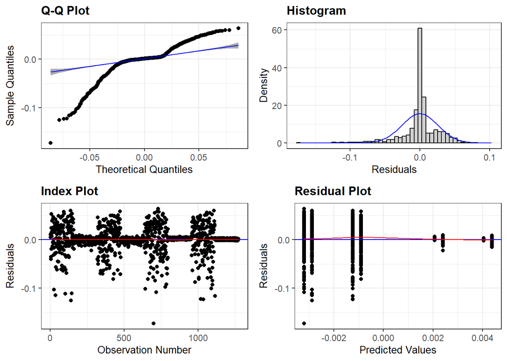

```r
#-------------------#
# Plots and Histograms

# Normality of residual
resid_auxpanel(model_1_7_corrected$residuals,
               model_1_7_corrected$fitted.values,
               plots = c("qq", "hist", "index", "resid"),
               smoother = TRUE, qqbands = TRUE, bins=50)
```

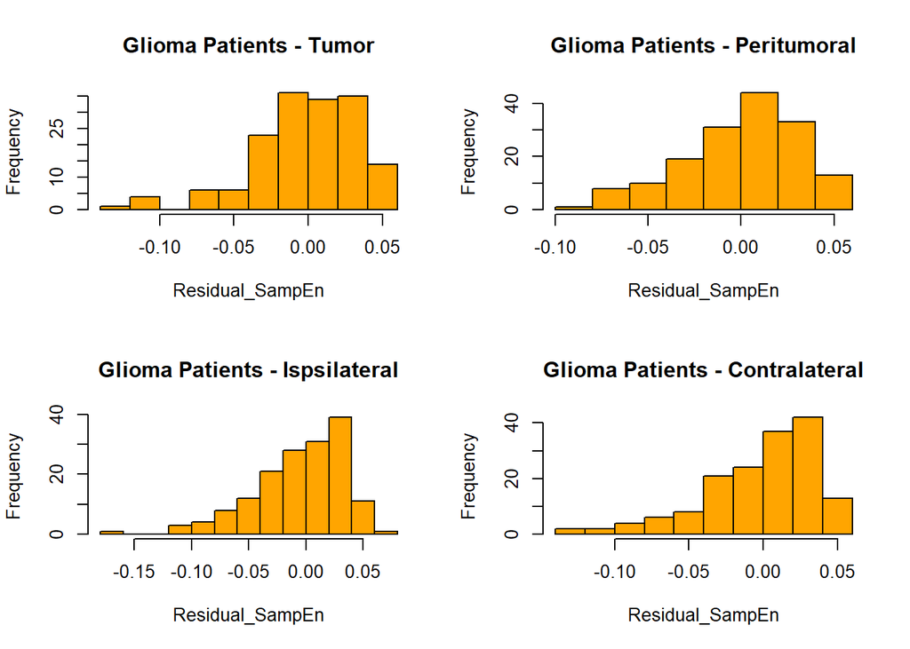

```r
# Normality per conditions
par(mfrow=c(2, 2))  # 2x2 layout for the plots
# Create filters to selected from outlier corrected data set
Filter_g_t_1_7 = filter(data_across_regions_1_7_corrected, Glioma_HC == "Glioma", en_variable == "en_tumor_1_7")
hist(Filter_g_t_1_7$score, main="Glioma Patients - Tumor", xlab = "Residual_SampEn", col="orange")
Filter_g_p_1_7 = filter(data_across_regions_1_7_corrected, Glioma_HC == "Glioma", en_variable == "en_peri_1_7")
hist(Filter_g_p_1_7$score, main="Glioma Patients - Peritumoral", xlab = "Residual_SampEn", col="orange")
Filter_g_i_1_7 = filter(data_across_regions_1_7_corrected, Glioma_HC == "Glioma", en_variable == "en_ipsi_1_7")
hist(Filter_g_i_1_7$score, main="Glioma Patients - Ispsilateral", xlab = "Residual_SampEn", col="orange")
Filter_g_c_1_7 = filter(data_across_regions_1_7_corrected, Glioma_HC == "Glioma", en_variable == "en_contra_1_7")
hist(Filter_g_c_1_7$score, main="Glioma Patients - Contralateral", xlab = "Residual_SampEn", col="orange")
```

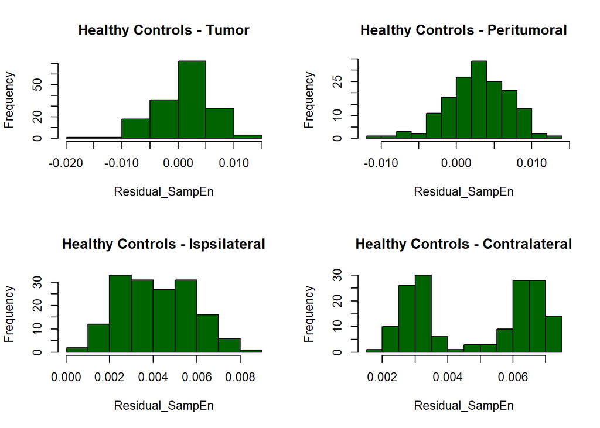

```r
Filter_h_t_1_7 = filter(data_across_regions_1_7_corrected, Glioma_HC == "HC", en_variable == "en_tumor_1_7")
hist(Filter_h_t_1_7$score, main="Healthy Controls - Tumor", xlab = "Residual_SampEn", col="darkgreen")
Filter_h_p_1_7 = filter(data_across_regions_1_7_corrected, Glioma_HC == "HC", en_variable == "en_peri_1_7")
hist(Filter_h_p_1_7$score, main="Healthy Controls - Peritumoral", xlab = "Residual_SampEn", col="darkgreen")
Filter_h_i_1_7 = filter(data_across_regions_1_7_corrected, Glioma_HC == "HC", en_variable == "en_ipsi_1_7")
hist(Filter_h_i_1_7$score, main="Healthy Controls - Ispsilateral", xlab = "Residual_SampEn", col="darkgreen")
Filter_g_c_1_7 = filter(data_across_regions_1_7_corrected, Glioma_HC == "HC", en_variable == "en_contra_1_7")
hist(Filter_g_c_1_7$score, main="Healthy Controls - Contralateral", xlab = "Residual_SampEn", col="darkgreen")
```

```r
# Reset the plotting configuration
par(mfrow=c(1, 1))  # Reset to default single plot


#-------------------#
# Robustness
# extract e.g., n per group that is of interest for robustness
data_across_regions_1_7_corrected %>%
  group_by(en_variable, Glioma_HC) %>%
  get_summary_stats(score, type = "mean_sd")
```

```
# A tibble: 8 × 6
  Glioma_HC en_variable   variable     n   mean    sd
  <chr>     <chr>         <fct>    <dbl>  <dbl> <dbl>
1 Glioma    en_contra_1_7 score      159 -0.002 0.038
2 HC        en_contra_1_7 score      159  0.005 0.002
3 Glioma    en_ipsi_1_7   score      159 -0.005 0.039
4 HC        en_ipsi_1_7   score      159  0.004 0.002
5 Glioma    en_peri_1_7   score      159  0.001 0.031
6 HC        en_peri_1_7   score      159  0.003 0.004
7 Glioma    en_tumor_1_7  score      159 -0.002 0.036
8 HC        en_tumor_1_7  score      159  0.001 0.005
```

Interpretation and Argumentation:

**Extreme Outliers** (n=‘see above’) were identified and excluded in this analysis

**Note about normality and variance assumptions:**  
*To all of the assumptions mentioned above ANOVA’s, just like t-tests, are “robust against the violations of the normality and equal variance assumptions if within-groups n’s are reasonable large”* (Applied Statistics I, Warner, 2021, p.377; also see p.486).  
*In greater detail about normality: “The results of these tests of normality often dependend more on sample size than on distribution shape (University College London). […] Some textbooks say that a normal distribution of scores in a sample is a required assumption for the use of many common statistics. Strictly speaking that is incorrect (Field, 2018).”* (Applied Statistics I, Warner, 2021, p.148f.)  
Especially the Shapiro test gets easily oversensitive with sample size exceeding n = 50 (Datanovia, ultimate guide for mixed design anova).  
On a general note, making interpretations of the histograms and graphs is more important.

Which assumptions are most **relevant**?  
No person-by-treatment interaction (tested above) and sphericity assumption (internally adjusted in ANOVA irrespective of significance and therefore not explicitly tested in this part).

## Testing Hypothesis 1: HC & Glioma differences (averaged version)

```r
# Type III sum of squares is used, whereas main effects get hardly interpretable if an interaction effect is present (sig or non-sig).
# Why did I not just use Type II? Inconsistencies in calculations if results were compared to SPSS


# Mixed ANOVA with Interaction term
res.aov_H1_corrected = anova_test(
  data = data_across_regions_1_7_corrected, dv = score, wid = Id,
  between = Glioma_HC, within = en_variable,
  effect.size = "pes", type=3, detailed = TRUE
)

# Mixed ANOVA for Main effects
# not always necessary or appropriate
res.aov_H1_main_corrected = anova_test(score ~ Glioma_HC + en_variable, data = data_across_regions_1_7_corrected, wid = Id,
  effect.size = "pes", type=3
)

# Extract ANOVA table
# GG specifies that the correction for sphericity will be done via Greenhouse-Geisser correction to all variables irrespective of their p-value on the GG test
anova_table_H1_corrected = get_anova_table(res.aov_H1_corrected, correction = "GG")
anova_table_H1_corrected
```

```
ANOVA Table (type III tests)

                 Effect  DFn    DFd      SSn   SSd     F     p p<.05   pes
1           (Intercept) 1.00 316.00 0.000432 0.304 0.449 0.503       0.001
2             Glioma_HC 1.00 316.00 0.009000 0.304 9.205 0.003     * 0.028
3           en_variable 2.66 841.53 0.001000 0.530 0.760 0.502       0.002
4 Glioma_HC:en_variable 2.66 841.53 0.003000 0.530 1.731 0.165       0.005
```

```r
anova_table_H1_main_corrected = get_anova_table(res.aov_H1_main_corrected, correction = "GG")
anova_table_H1_main_corrected
```

```
ANOVA Table (type III tests)

       Effect DFn  DFd      F        p p<.05   pes
1   Glioma_HC   1 1267 13.409 0.000261     * 0.010
2 en_variable   3 1267  0.644 0.587000       0.002
```

```r
#-------------------
# This following part has most relevance if interaction terms or main effects are significant. If not, following test should not be reported or executed.
# You can find post-hoc one way ANOVAs, effect size calculations and contrasts underneath

# One way group / subjects variable | Effect of subject on each time point
data_across_regions_1_7_corrected %>%
  group_by(en_variable) %>%
  anova_test(dv = score, wid = Id, between = Glioma_HC) %>%
  get_anova_table() %>%
  adjust_pvalue(method = "bonferroni")
```

```
# A tibble: 4 × 9
  en_variable   Effect      DFn   DFd     F     p `p<.05`   ges p.adj
  <chr>         <chr>     <dbl> <dbl> <dbl> <dbl> <chr>   <dbl> <dbl>
1 en_contra_1_7 Glioma_HC     1   316 5.13  0.024 "*"     0.016 0.096
2 en_ipsi_1_7   Glioma_HC     1   316 9.12  0.003 "*"     0.028 0.012
3 en_peri_1_7   Glioma_HC     1   316 0.727 0.394 ""      0.002 1
4 en_tumor_1_7  Glioma_HC     1   316 0.9   0.344 ""      0.003 1
```

```r
# The evaluation of Cohen’s D can be obtained with bootstrapping
#data_across_regions_1_7_corrected %>%
#  group_by(en_variable) %>%
#  cohens_d(score ~ Glioma_HC, paired = TRUE,
#        var.equal = FALSE, ci = TRUE, conf.level = 0.95)


# One way location variable | Effect of Location upon subject
data_across_regions_1_7_corrected %>%
  group_by(Glioma_HC) %>%
  anova_test(dv = score, wid = Id, between = en_variable) %>%
  get_anova_table() %>%
  adjust_pvalue(method = "bonferroni")
```

```
# A tibble: 2 × 9
  Glioma_HC Effect        DFn   DFd     F        p `p<.05`   ges    p.adj
  <chr>     <chr>       <dbl> <dbl> <dbl>    <dbl> <chr>   <dbl>    <dbl>
1 Glioma    en_variable     3   632  0.74 5.28e- 1 ""      0.004 1   e+ 0
2 HC        en_variable     3   632 35.1  5.23e-21 "*"     0.143 1.05e-20
```

```r
# Contrast: Might be unnecessary
# Pairwise comparisons between group levels
Paired_t_tests = data_across_regions_1_7_corrected %>%
   group_by(Glioma_HC) %>%
   t_test(score ~ en_variable, p.adjust.method = "bonferroni", detailed = TRUE, paired = TRUE) # Must be true if it is a dependent test
print(Paired_t_tests, width = Inf)
```

```
# A tibble: 12 × 16
   Glioma_HC  estimate .y.   group1        group2          n1    n2 statistic
 * <chr>         <dbl> <chr> <chr>         <chr>        <int> <int>     <dbl>
 1 Glioma     0.00327  score en_contra_1_7 en_ipsi_1_7    159   159     0.979
 2 Glioma    -0.00273  score en_contra_1_7 en_peri_1_7    159   159    -0.735
 3 Glioma    -0.000418 score en_contra_1_7 en_tumor_1_7   159   159    -0.103
 4 Glioma    -0.00599  score en_ipsi_1_7   en_peri_1_7    159   159    -1.62
 5 Glioma    -0.00368  score en_ipsi_1_7   en_tumor_1_7   159   159    -0.865
 6 Glioma     0.00231  score en_peri_1_7   en_tumor_1_7   159   159     0.713
 7 HC         0.000673 score en_contra_1_7 en_ipsi_1_7    159   159     2.63
 8 HC         0.00205  score en_contra_1_7 en_peri_1_7    159   159     5.56
 9 HC         0.00370  score en_contra_1_7 en_tumor_1_7   159   159     8.49
10 HC         0.00137  score en_ipsi_1_7   en_peri_1_7    159   159     4.00
11 HC         0.00303  score en_ipsi_1_7   en_tumor_1_7   159   159     7.23
12 HC         0.00165  score en_peri_1_7   en_tumor_1_7   159   159     4.02
          p    df  conf.low conf.high method alternative    p.adj p.adj.signif
 *    <dbl> <dbl>     <dbl>     <dbl> <chr>  <chr>          <dbl> <chr>
 1 3.29e- 1   158 -0.00332    0.00986 T-test two.sided   1   e+ 0 ns
 2 4.63e- 1   158 -0.0100     0.00460 T-test two.sided   1   e+ 0 ns
 3 9.18e- 1   158 -0.00841    0.00757 T-test two.sided   1   e+ 0 ns
 4 1.08e- 1   158 -0.0133     0.00132 T-test two.sided   6.48e- 1 ns
 5 3.88e- 1   158 -0.0121     0.00473 T-test two.sided   1   e+ 0 ns
 6 4.77e- 1   158 -0.00408    0.00869 T-test two.sided   1   e+ 0 ns
 7 9   e- 3   158  0.000168   0.00118 T-test two.sided   5.6 e- 2 ns
 8 1.10e- 7   158  0.00132    0.00277 T-test two.sided   6.60e- 7 ****
 9 1.39e-14   158  0.00284    0.00456 T-test two.sided   8.34e-14 ****
10 9.74e- 5   158  0.000695   0.00205 T-test two.sided   5.84e- 4 ***
11 1.96e-11   158  0.00220    0.00385 T-test two.sided   1.18e-10 ****
12 9   e- 5   158  0.000841   0.00247 T-test two.sided   5.4 e- 4 ***
```

```r
# The evaluation of the effect size is obtain with bootstrapping
#data_across_regions_1_7_corrected %>%
#  group_by(Glioma_HC) %>%
#  cohens_d(score ~ en_variable, paired = TRUE,
#        var.equal = FALSE, ci = TRUE, conf.level = 0.95)
```

Here you first should report the output of the interaction terms in the ANOVA.  
Afterwards, main effect are being conducted and supplement by e.g., simple effects.

## Visualize Hypothesis 1

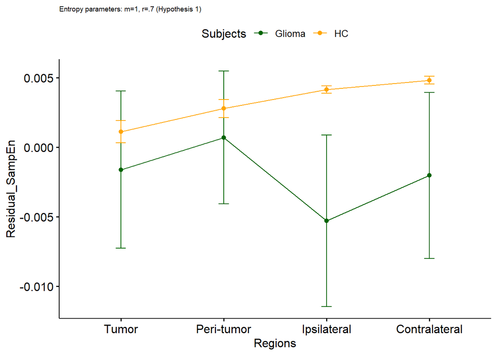

```r
## Visualizations of the data (not the prediction of the model)

# Create ggline for HC/Glioma difference
ggline(data_across_regions_1_7_corrected,
                          x = "en_variable",
                          y = "score",
                          color = "Glioma_HC",
                          add = "mean_ci", "dotplot") + #CI=95%
  labs(x = "Regions",
       y = "Residual_SampEn",
       color = "Subjects") +     # Legend title
  scale_x_discrete(labels = c("en_tumor_1_7" = "Tumor",        # Custom labels for each level
                              "en_peri_1_7" = "Peri-tumor",
                              "en_ipsi_1_7" = "Ipsilateral",
                              "en_contra_1_7" = "Contralateral"))  +
  labs(subtitle = "Entropy parameters: m=1, r=.7 (Hypothesis 1)") +
  theme(plot.subtitle = element_text(size = 7))+
  scale_color_manual(values = c("darkgreen", "orange"))
```

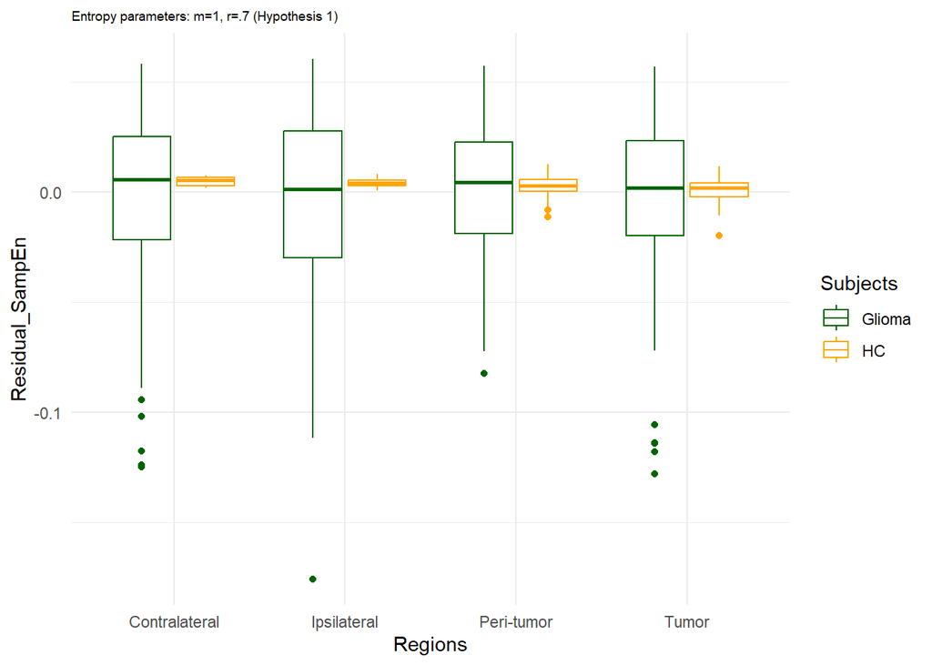

```r
# Create boxplot for HC/Glioma difference
ggplot(data_across_regions_1_7_corrected, aes(x = en_variable,
                                            y = score,
                                            color = Glioma_HC)) +
  geom_boxplot() +
  labs(x = "en_variable",
       y = "Score",
       color = "Glioma_HC") +
  theme_minimal() +
  labs(x = "Regions",
       y = "Residual_SampEn",
       color = "Subjects") +     # Legend title
  scale_x_discrete(labels = c("en_tumor_1_7" = "Tumor",        # Custom labels for each level
                              "en_peri_1_7" = "Peri-tumor",
                              "en_ipsi_1_7" = "Ipsilateral",
                              "en_contra_1_7" = "Contralateral")) +
  labs(subtitle = "Entropy parameters: m=1, r=.7 (Hypothesis 1)") +
  theme(plot.subtitle = element_text(size = 7)) +
  scale_color_manual(values = c("darkgreen", "orange"))
```

These plots (especially ggline) should be in line with the simple effects results. Double check the conclusions. The graphs created can be best compared across different parameter choices.

## Hypotheses 2-3: Assumptions and Outlier correction

```r
# Identify Outliers
outliers_H2_H3 <- data_across_regions_H2_H3_1_7 %>%
  group_by(en_variable, Grading) %>%
  identify_outliers(score)

outliers_H2_H3 %>% # Report as.outlier
  select(en_variable, Grading, score) %>%
  print(n = Inf)
```

```
# A tibble: 16 × 3
   en_variable                     Grading   score
   <chr>                           <chr>     <dbl>
 1 baselinecorrected_contralateral HGG     -0.121
 2 baselinecorrected_contralateral HGG     -0.114
 3 baselinecorrected_contralateral LGG     -0.121
 4 baselinecorrected_contralateral LGG     -0.179
 5 baselinecorrected_contralateral LGG     -0.0903
 6 baselinecorrected_contralateral LGG     -0.0916
 7 baselinecorrected_ipsilateral   LGG     -0.170
 8 baselinecorrected_ipsilateral   LGG     -0.131
 9 baselinecorrected_peritumor     LGG     -0.0759
10 baselinecorrected_peritumor     LGG     -0.0684
11 baselinecorrected_peritumor     LGG     -0.0627
12 baselinecorrected_peritumor     LGG     -0.0564
13 baselinecorrected_tumor         HGG     -0.112
14 baselinecorrected_tumor         HGG     -0.111
15 baselinecorrected_tumor         HGG     -0.118
16 baselinecorrected_tumor         LGG     -0.154
```

```r
outliers_H2_H3_extreme = filter(outliers_H2_H3, is.extreme == TRUE) # Report is.extreme

outliers_H2_H3_extreme %>% # Report as_extreme.outlier
  print(n = Inf)
```

```
# A tibble: 3 × 32
  Grading en_variable                Id    Nr    PatientNr sex   education_years
  <chr>   <chr>                      <chr> <chr> <chr>     <chr>           <dbl>
1 LGG     baselinecorrected_contral… 81    81    1184      fema…              13
2 LGG     baselinecorrected_ipsilat… 63    63    0754      fema…              11
3 LGG     baselinecorrected_tumor    128   128   1737      male               14
# ℹ 25 more variables: education_Verhage <dbl>, education_low <chr>,
#   education_high <chr>, education_total <chr>, Bijz_PA_diagn <chr>,
#   PA_diagnose <chr>, Gedrag_tumor <chr>, Diffgrad_tumor <chr>, HGG_LGG <chr>,
#   Glioma_HC <chr>, NPS_0_NPS_afname_T0_ja_nee <chr>, age_T0 <dbl>,
#   en_tumor_1_7 <dbl>, en_peri_1_7 <dbl>, en_ipsi_1_7 <dbl>,
#   en_contra_1_7 <dbl>, tumor_volume_mm3 <dbl>, peri_volume_mm3 <dbl>,
#   ipsi_volume_mm3 <dbl>, contra_volume_mm3 <dbl>, score <dbl>, …
```

```r
# Row counts are included to see if exclusion worked correctly
# Old row - new row = extreme_outlier*4 (whole participant excluded)
row_count <- nrow(data_across_regions_H2_H3_1_7)
row_count
```

```
[1] 644
```

```r
# Pull ID numbers to exclude
# Exclusion by ID numbers to sustain paired sample t-tests later on
# In other words extreme outlier are excluded and would lead to missing data
# Missing data will unequalize the groups making paired (dependent) post hoc tests impossible
# Instead exclude participant as a whole (all 4 observations from data set)
# This is justifiable with the very small proportion of actual exclusions
data_across_regions_H2_H3_1_7_corrected <- data_across_regions_H2_H3_1_7 %>%
  anti_join(outliers_H2_H3_extreme, by = "Id")
# you can either use the filtered (extreme) or general outlier version; in this case extreme.

#IMPORTANT: If you want to reproduce with SPSS you need to make this part unusable by putting appropriate hashtags!
#    'data_across_regions__H2_H3_1_7_corrected <- data_across_regions_1_7 # %>%'
#   '#anti_join(outliers_H2_H3, by = c("en_variable", "Glioma_HC", "score"))'


# 'anti_join' removes rows from the dataset that have a match in this case with Id.
# Now 'cleaned_data' = data_across_regions_1_7_corrected contains all the data except for the identified outliers subjects (across the 4 ROIs)
row_count <- nrow(data_across_regions_H2_H3_1_7_corrected)
row_count
```

```
[1] 632
```

```r
# Testing assumptions

# Normality assumptions
# Normality of variables
data_across_regions_H2_H3_1_7_corrected %>%
  group_by(en_variable, Grading) %>%
  shapiro_test(score)
```

```
# A tibble: 8 × 5
  Grading en_variable                     variable statistic        p
  <chr>   <chr>                           <chr>        <dbl>    <dbl>
1 HGG     baselinecorrected_contralateral score        0.932 0.000233
2 LGG     baselinecorrected_contralateral score        0.936 0.00113
3 HGG     baselinecorrected_ipsilateral   score        0.949 0.00213
4 LGG     baselinecorrected_ipsilateral   score        0.964 0.0364
5 HGG     baselinecorrected_peritumor     score        0.967 0.0279
6 LGG     baselinecorrected_peritumor     score        0.944 0.00290
7 HGG     baselinecorrected_tumor         score        0.933 0.000251
8 LGG     baselinecorrected_tumor         score        0.970 0.0744
```

```r
# Normality of residuals
# Note: A different model function is used because the Anova function from rstatix does not support extracting residuals
# No great differences are expected and justify usage
model_H2_H3_1_7_corrected = lm(score ~ en_variable + Grading + sex + age_T0, data = data_across_regions_H2_H3_1_7_corrected)

shapiro_test(model_H2_H3_1_7_corrected$residuals)
```

```
# A tibble: 1 × 3
  variable                            statistic  p.value
  <chr>                                   <dbl>    <dbl>
1 model_H2_H3_1_7_corrected$residuals     0.960 4.64e-12
```

```r
# Homogeneity of variance
# Coercion because of categorical data. So warnings should be fine.
data_across_regions_H2_H3_1_7_corrected %>%
  group_by(en_variable) %>%
  levene_test(score ~ Grading)
```

```
# A tibble: 4 × 5
  en_variable                       df1   df2 statistic       p
  <chr>                           <int> <int>     <dbl>   <dbl>
1 baselinecorrected_contralateral     1   156     2.46  0.119
2 baselinecorrected_ipsilateral       1   156     5.27  0.0231
3 baselinecorrected_peritumor         1   156     0.312 0.577
4 baselinecorrected_tumor             1   156     9.84  0.00205
```

```r
# Homogeneity of Covariance
box_m(data_across_regions_H2_H3_1_7_corrected[, "score", drop = FALSE], data_across_regions_H2_H3_1_7_corrected$Grading)
```

```
# A tibble: 1 × 4
  statistic   p.value parameter method
      <dbl>     <dbl>     <dbl> <chr>
1      19.3 0.0000110         1 Box's M-test for Homogeneity of Covariance Matr…
```

```r
# Test No person-by-treatment interaction
tukey.add.test(data_across_regions_H2_H3_1_7_corrected$score, data_across_regions_H2_H3_1_7_corrected$en_variable, data_across_regions_H2_H3_1_7_corrected$Grading)
```

```
Tukey's one df test for additivity
F = 0.0004326   Denom df = 626    p-value = 0.9834129
```

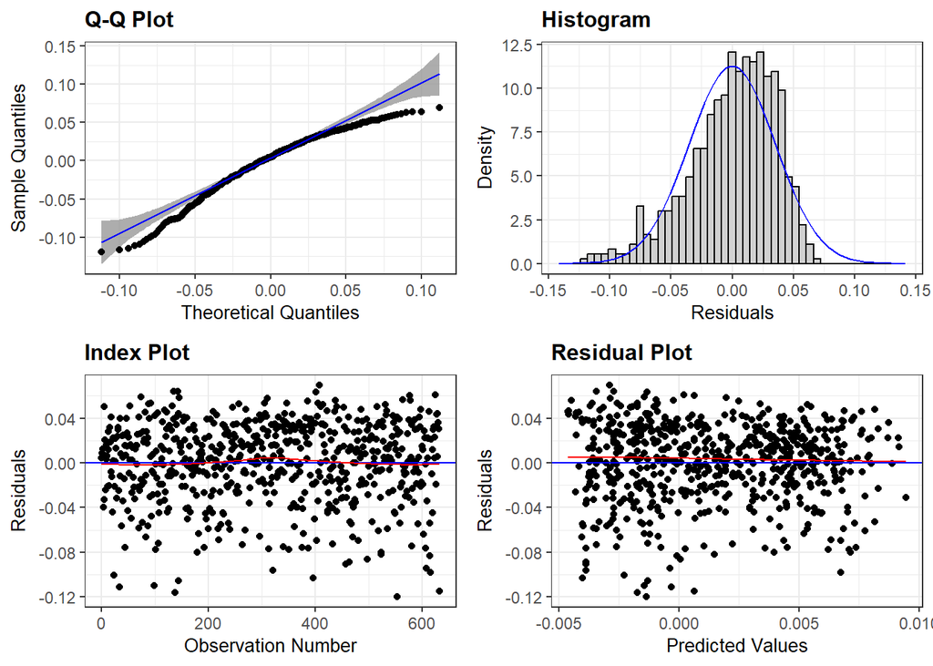

```r
#-------------------#
# Plots and Histograms

# Normality of residual
resid_auxpanel(model_H2_H3_1_7_corrected$residuals,
               model_H2_H3_1_7_corrected$fitted.values,
               plots = c("qq", "hist", "index", "resid"),
               smoother = TRUE, qqbands = TRUE, bins=50)
```

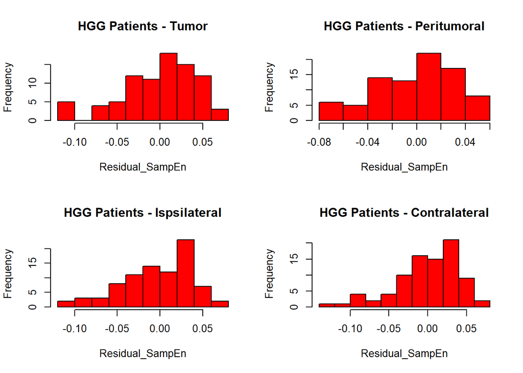

```r
# Normality per conditions
par(mfrow=c(2, 2))  # 2x2 layout for the plots
# Create filters to selected from outlier corrected data set
Filter_g_t_1_7 = filter(data_across_regions_H2_H3_1_7_corrected, Grading == "HGG", en_variable == "baselinecorrected_tumor")
hist(Filter_g_t_1_7$score, main="HGG Patients - Tumor", xlab = "Residual_SampEn", col="red")
Filter_g_p_1_7 = filter(data_across_regions_H2_H3_1_7_corrected, Grading == "HGG", en_variable == "baselinecorrected_peritumor")
hist(Filter_g_p_1_7$score, main="HGG Patients - Peritumoral", xlab = "Residual_SampEn", col="red")
Filter_g_i_1_7 = filter(data_across_regions_H2_H3_1_7_corrected, Grading == "HGG", en_variable == "baselinecorrected_ipsilateral")
hist(Filter_g_i_1_7$score, main="HGG Patients - Ispsilateral", xlab = "Residual_SampEn", col="red")
Filter_g_c_1_7 = filter(data_across_regions_H2_H3_1_7_corrected, Grading == "HGG", en_variable == "baselinecorrected_contralateral")
hist(Filter_g_c_1_7$score, main="HGG Patients - Contralateral", xlab = "Residual_SampEn", col="red")
```

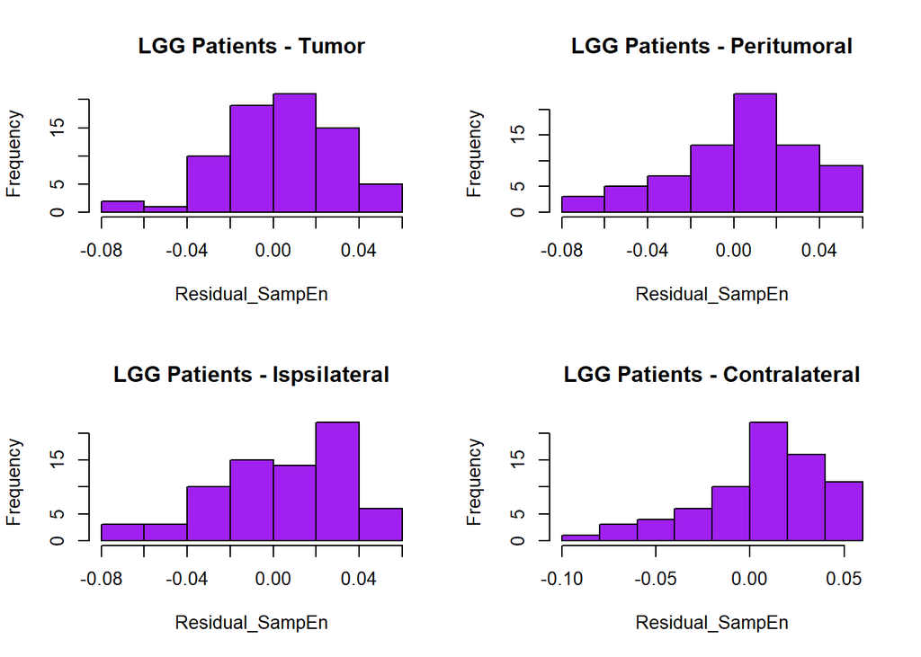

```r
Filter_h_t_1_7 = filter(data_across_regions_H2_H3_1_7_corrected, Grading == "LGG", en_variable == "baselinecorrected_tumor")
hist(Filter_h_t_1_7$score, main="LGG Patients - Tumor", xlab = "Residual_SampEn", col="purple")
Filter_h_p_1_7 = filter(data_across_regions_H2_H3_1_7_corrected, Grading == "LGG", en_variable == "baselinecorrected_peritumor")
hist(Filter_h_p_1_7$score, main="LGG Patients - Peritumoral", xlab = "Residual_SampEn", col="purple")
Filter_h_i_1_7 = filter(data_across_regions_H2_H3_1_7_corrected, Grading == "LGG", en_variable == "baselinecorrected_ipsilateral")
hist(Filter_h_i_1_7$score, main="LGG Patients - Ispsilateral", xlab = "Residual_SampEn", col="purple")
Filter_g_c_1_7 = filter(data_across_regions_H2_H3_1_7_corrected, Grading == "LGG", en_variable == "baselinecorrected_contralateral")
hist(Filter_g_c_1_7$score, main="LGG Patients - Contralateral", xlab = "Residual_SampEn", col="purple")
```

```r
# Reset the plotting configuration
par(mfrow=c(1, 1))  # Reset to default single plot



#-------------------#

# Robustness:
# extract e.g., n per group that is of interest for robustness
data_across_regions_H2_H3_1_7_corrected %>%
  group_by(en_variable, Grading) %>%
  get_summary_stats(score, type = "mean_sd")
```

```
# A tibble: 8 × 6
  Grading en_variable                     variable     n   mean    sd
  <chr>   <chr>                           <fct>    <dbl>  <dbl> <dbl>
1 HGG     baselinecorrected_contralateral score       85  0     0.04
2 LGG     baselinecorrected_contralateral score       73  0.007 0.033
3 HGG     baselinecorrected_ipsilateral   score       85 -0.003 0.041
4 LGG     baselinecorrected_ipsilateral   score       73  0.004 0.032
5 HGG     baselinecorrected_peritumor     score       85 -0.001 0.032
6 LGG     baselinecorrected_peritumor     score       73  0.004 0.031
7 HGG     baselinecorrected_tumor         score       85 -0.001 0.043
8 LGG     baselinecorrected_tumor         score       73  0.003 0.027
```

Interpretation and Argumentation:

**Outliers** (n=‘see above’) were identified and excluded in this analysis

**Note about normality and variance assumptions:**  
*To all of the assumptions mentioned above ANOVA’s, just like t-tests, are “robust against the violations of the normality and equal variance assumptions if within-groups n’s are reasonable large”* (Applied Statistics I, Warner, 2021, p.377; also see p.486).  
*In greater detail about normality: “The results of these tests of normality often dependend more on sample size than on distribution shape (University College London). […] Some textbooks say that a normal distribution of scores in a sample is a required assumption for the use of many common statistics. Strictly speaking that is incorrect (Field, 2018).”* (Applied Statistics I, Warner, 2021, p.148f.)  
Especially the Shapiro test gets easily oversensitive with sample size exceeding n = 50 (Datanovia, ultimate guide for mixed design anova).  
On a general note, making interpretations of the histograms and graphs is more important.

Which assumptions are most **relevant**?  
No person-by-treatment interaction (tested above) and sphericity assumption (internally adjusted in ANOVA irrespective of significance and therefore not explicitly tested in this part).

## Testing Hypotheses 2-3: LGG & HGG differences (1-to-1)

```r
# Type III sum of squares is used, whereas main effects get hardly interpretable if an interaction effect is present (sig or non-sig).
# Why did I not just use Type II? Inconsistencies in calculations if results were compared to SPSS

# Mixed ANOVA with interaction
res.aov_H2_H3_corrected = anova_test(
  data = data_across_regions_H2_H3_1_7_corrected, dv = score, wid = Id,
  between = Grading, within = en_variable,
  covariate = c(age_T0, sex),
  effect.size = "pes", type=3, detailed = TRUE
)

# Mixed ANOVA for Main effects
# not always necessary or appropriate
res.aov_H2_H3_main_corrected = anova_test(score ~ Grading + en_variable + age_T0 + sex, data = data_across_regions_H2_H3_1_7_corrected, wid = Id,
  effect.size = "pes", type=3
)

# Extract ANOVA table
# GG specifies that the correction for sphericity will be done via Greenhouse-Geisser correction to all variables irrespective of their p-value on the GG test
anova_table_H2_H3_corrected = get_anova_table(res.aov_H2_H3_corrected, correction = "GG")
anova_table_H2_H3_corrected
```

```
ANOVA Table (type III tests)

               Effect  DFn    DFd      SSn   SSd     F     p p<.05     pes
1         (Intercept) 1.00 154.00 3.00e-03 0.287 1.425 0.234       9.0e-03
2              age_T0 1.00 154.00 2.00e-03 0.287 0.974 0.325       6.0e-03
3                 sex 1.00 154.00 3.46e-06 0.287 0.002 0.966       1.2e-05
4             Grading 1.00 154.00 2.00e-03 0.287 0.820 0.367       5.0e-03
5         en_variable 2.74 421.59 5.30e-04 0.499 0.163 0.907       1.0e-03
6  age_T0:en_variable 2.74 421.59 7.63e-04 0.499 0.235 0.855       2.0e-03
7     sex:en_variable 2.74 421.59 2.00e-03 0.499 0.505 0.662       3.0e-03
8 Grading:en_variable 2.74 421.59 6.55e-04 0.499 0.202 0.879       1.0e-03
```

```r
anova_table_H2_H3_main_corrected = get_anova_table(res.aov_H2_H3_main_corrected, correction = "GG")
anova_table_H2_H3_main_corrected
```

```
ANOVA Table (type III tests)

       Effect DFn DFd     F     p p<.05      pes
1     Grading   1 625 1.211 0.272       2.00e-03
2 en_variable   3 625 0.178 0.911       8.54e-04
3      age_T0   1 625 1.438 0.231       2.00e-03
4         sex   1 625 0.003 0.958       4.38e-06
```

```r
#-------------------------------------
# This following part has most relevance if interaction terms or main effects are significant. If not, following test should not be reported or executed.
# You can find post-hoc one way ANOVAs, effect size calculations and contrasts underneath


# One way group / subjects variable | Effect of subject on each time point
data_across_regions_H2_H3_1_7_corrected %>%
  group_by(en_variable) %>%
  anova_test(dv = score, wid = Id, between = Grading) %>%
  get_anova_table() %>%
  adjust_pvalue(method = "bonferroni")
```

```
# A tibble: 4 × 9
  en_variable                 Effect   DFn   DFd     F     p `p<.05`   ges p.adj
  <chr>                       <chr>  <dbl> <dbl> <dbl> <dbl> <chr>   <dbl> <dbl>
1 baselinecorrected_contrala… Gradi…     1   156 1.36  0.245 ""      0.009 0.98
2 baselinecorrected_ipsilate… Gradi…     1   156 1.39  0.241 ""      0.009 0.964
3 baselinecorrected_peritumor Gradi…     1   156 0.989 0.322 ""      0.006 1
4 baselinecorrected_tumor     Gradi…     1   156 0.559 0.456 ""      0.004 1
```

```r
# The evaluation of the effect size is obtained with bootstrapping
#data_across_regions_H2_H3_1_7 %>%
#  group_by(en_variable) %>%
#  cohens_d(score ~ Grading, paired = TRUE,
#        var.equal = FALSE, ci = TRUE, conf.level = 0.95)


# One way location variable | Effect of Location upon subject
data_across_regions_H2_H3_1_7_corrected %>%
  group_by(Grading) %>%
  anova_test(dv = score, wid = Nr, between = en_variable) %>%
  get_anova_table() %>%
  adjust_pvalue(method = "bonferroni")
```

```
# A tibble: 2 × 9
  Grading Effect        DFn   DFd     F     p `p<.05`      ges p.adj
  <chr>   <chr>       <dbl> <dbl> <dbl> <dbl> <chr>      <dbl> <dbl>
1 HGG     en_variable     3   336 0.073 0.974 ""      0.000651     1
2 LGG     en_variable     3   288 0.192 0.902 ""      0.002        1
```

```r
# Pairwise comparisons between group levels
Paired_t_testsH23 = data_across_regions_H2_H3_1_7_corrected %>%
   group_by(Grading) %>%
   t_test(score ~ en_variable, p.adjust.method = "bonferroni", detailed = TRUE, paired = TRUE) # Must be true if it is a dependent test
print(Paired_t_testsH23, width = Inf)
```

```
# A tibble: 12 × 16
   Grading   estimate .y.   group1
 * <chr>        <dbl> <chr> <chr>
 1 HGG      0.00270   score baselinecorrected_contralateral
 2 HGG      0.000638  score baselinecorrected_contralateral
 3 HGG      0.00119   score baselinecorrected_contralateral
 4 HGG     -0.00206   score baselinecorrected_ipsilateral
 5 HGG     -0.00151   score baselinecorrected_ipsilateral
 6 HGG      0.000551  score baselinecorrected_peritumor
 7 LGG      0.00263   score baselinecorrected_contralateral
 8 LGG      0.00253   score baselinecorrected_contralateral
 9 LGG      0.00371   score baselinecorrected_contralateral
10 LGG     -0.0000943 score baselinecorrected_ipsilateral
11 LGG      0.00108   score baselinecorrected_ipsilateral
12 LGG      0.00118   score baselinecorrected_peritumor
```

[output cut: 28 more lines]

```r
# The evaluation of the effect size is obtained with bootstrapping
#data_across_regions_H2_H3_1_7_corrected %>%
#  group_by(Grading) %>%
#  cohens_d(score ~ en_variable, paired = TRUE,
#        var.equal = FALSE, ci = TRUE, conf.level = 0.95)
```

Here you first should report the output of the interaction terms in the ANOVA.  
Afterwards, main effect are being conducted and supplement by e.g. simple effects.

## Visualize Hypotheses 2-3

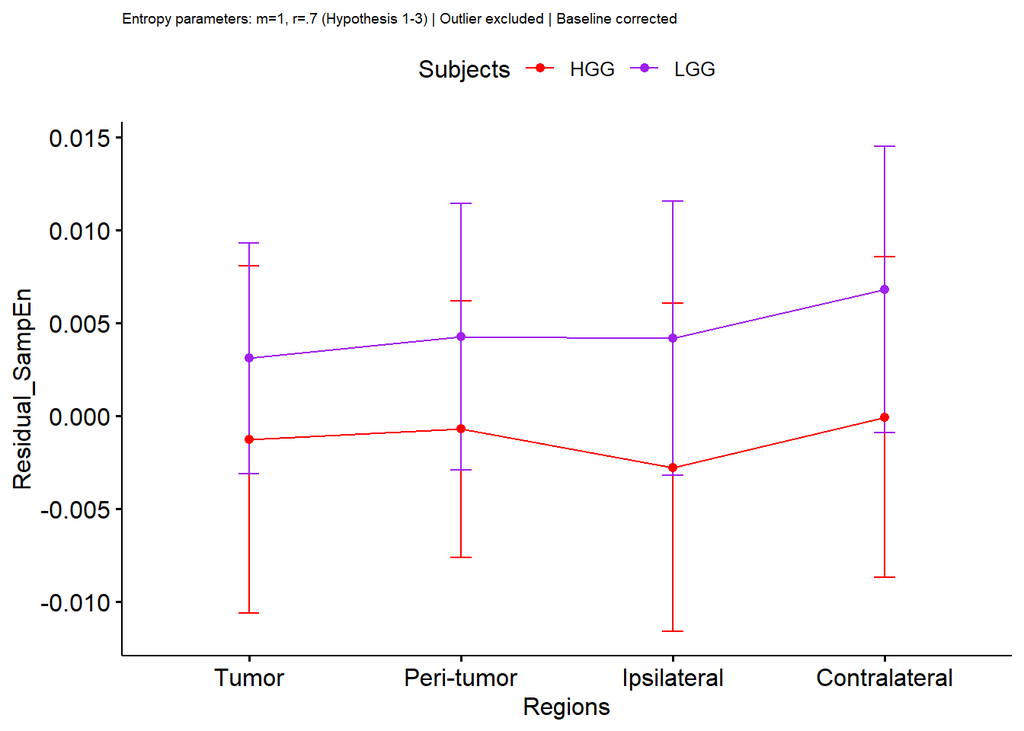

```r
# Create the ggline plot for all conditions
ggline(data_across_regions_H2_H3_1_7_corrected,
       x = "en_variable",
       y = "score",
       color = "Grading",
       add = "mean_ci", type = "dotplot") +
  labs(x = "Regions",
       y = "Residual_SampEn",
       color = "Subjects") +     # Legend title
  scale_x_discrete(labels = c("baselinecorrected_tumor" = "Tumor",        # Custom labels for each level
                              "baselinecorrected_peritumor" = "Peri-tumor",
                              "baselinecorrected_ipsilateral" = "Ipsilateral",
                              "baselinecorrected_contralateral" = "Contralateral")) +
  labs(subtitle = "Entropy parameters: m=1, r=.7 (Hypothesis 1-3) | Outlier excluded | Baseline corrected") +
  theme(plot.subtitle = element_text(size = 7))+
  scale_color_manual(values = c("red", "purple"))
```

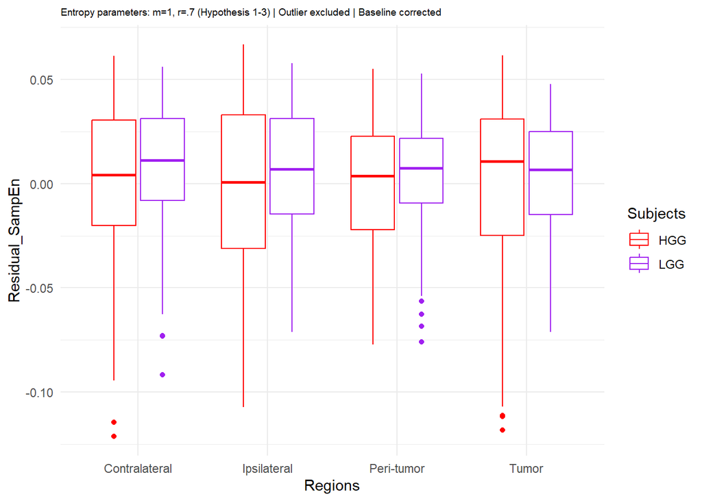

```r
# Create boxplot with color for all conditions
ggplot(data_across_regions_H2_H3_1_7_corrected, aes(x = en_variable,
                                                    y = score,
                                                    color = Grading)) +
  geom_boxplot() +
  labs(x = "Regions",
       y = "Residual_SampEn",
       color = "Subjects") +    # Legend title
  theme_minimal() +
  scale_x_discrete(labels = c("baselinecorrected_tumor" = "Tumor",            # Custom labels for each level
                              "baselinecorrected_peritumor" = "Peri-tumor",
                              "baselinecorrected_ipsilateral" = "Ipsilateral",
                              "baselinecorrected_contralateral" = "Contralateral")) +
  labs(subtitle = "Entropy parameters: m=1, r=.7 (Hypothesis 1-3) | Outlier excluded | Baseline corrected") +
  theme(plot.subtitle = element_text(size = 7)) +
  scale_color_manual(values = c("red", "purple"))
```

These plots (especially ggline) should be in line with simple effects results. Double check the conclusions. The graphs created can be best compared across different parameter choices.

## Visualizations across Hypotheses

### [Conceputally / Practically including the baseline is not suited, wherefore this would not included the adjusted analysis for H2/H3]

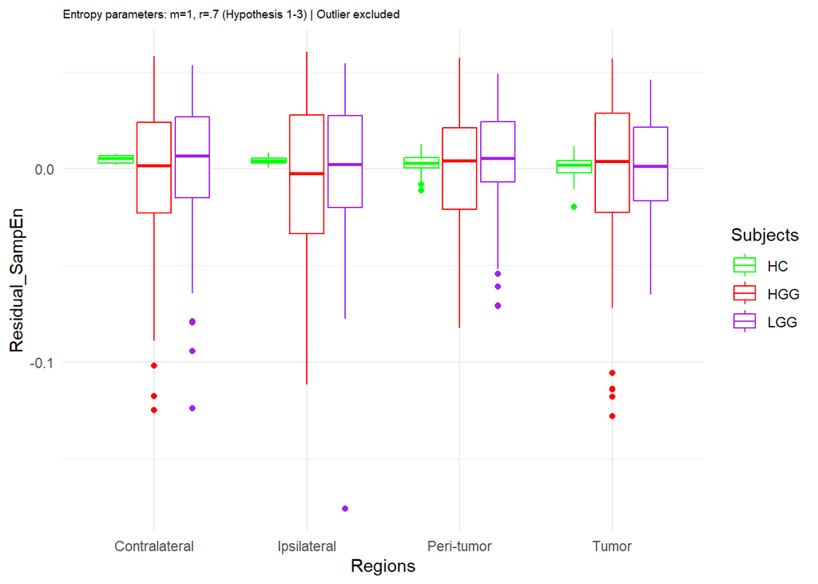

```r
# Create boxplot with color for all conditions
ggplot(data_across_regions_1_7_corrected, aes(x = en_variable,
                                            y = score,
                                            color = Grading)) +
  geom_boxplot() +
  labs(x = "en_variable",
       y = "Score",
       color = "Grading") +
  theme_minimal() +
  labs(x = "Regions",
       y = "Residual_SampEn",
       color = "Subjects") +     # Legend title
  scale_x_discrete(labels = c("en_tumor_1_7" = "Tumor",        # Custom labels for each level
                              "en_peri_1_7" = "Peri-tumor",
                              "en_ipsi_1_7" = "Ipsilateral",
                              "en_contra_1_7" = "Contralateral")) +
  labs(subtitle = "Entropy parameters: m=1, r=.7 (Hypothesis 1-3) | Outlier excluded") +
  theme(plot.subtitle = element_text(size = 7))+
  scale_color_manual(values = c("green", "red", "purple"))
```

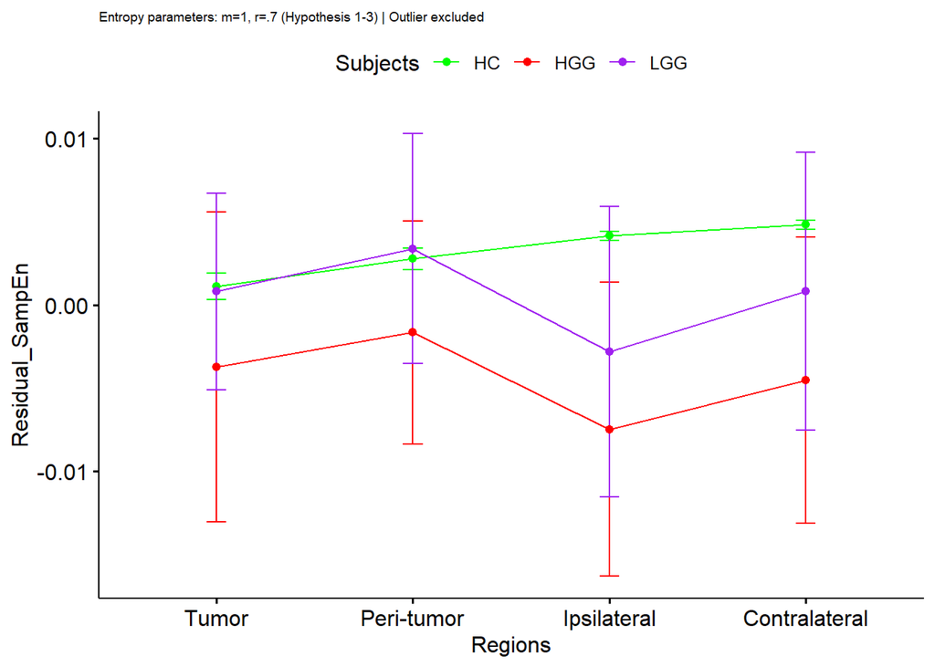

```r
# Create the ggline plot for all conditions
ggline(data_across_regions_1_7_corrected,
                          x = "en_variable",
                          y = "score",
                          color = "Grading",
                          add = "mean_ci", "dotplot") + # 95%
  labs(x = "Regions",
       y = "Residual_SampEn",
       color = "Subjects",
      ) +     # Legend title
  scale_x_discrete(labels = c("en_tumor_1_7" = "Tumor",        # Custom labels for each level
                              "en_peri_1_7" = "Peri-tumor",
                              "en_ipsi_1_7" = "Ipsilateral",
                              "en_contra_1_7" = "Contralateral")) +
  labs(subtitle = "Entropy parameters: m=1, r=.7 (Hypothesis 1-3) | Outlier excluded") +
  theme(plot.subtitle = element_text(size = 7)) +
  scale_color_manual(values = c("green", "red", "purple"))
```